# ASSOCIATIONAL ANALYSIS

ROTICH HARON

2/8/2022

```r
# We first we install the required arules library
#
#install.packages("arules")
#install and load arulesViz
#install.packages("arulesViz")
library(arulesViz)
#install and load tidyverse
#install.packages("tidyverse")
library(tidyverse)
library(arules)
```

```r
# loading data
path <- "C:/Users/hp/Downloads/groceries - groceries.csv"
df<- read_csv(path,',')
# coverting the basket to transactional class
tr <- read.transactions(path, sep=',')
#sep tell how items are separated. In this case you have separated using ','
```

```r
class(tr)
```

```
## [1] "transactions"
## attr(,"package")
## [1] "arules"
```

```r
tr
```

```
## transactions in sparse format with
##  9836 transactions (rows) and
##  231 items (columns)
```

```r
summary(tr)
```

```
## transactions as itemMatrix in sparse format with
##  9836 rows (elements/itemsets/transactions) and
##  231 columns (items) and a density of 0.0234297
##
## most frequent items:
##       whole milk                1 other vegetables       rolls/buns
##             2513             2159             1903             1809
##             soda          (Other)
##             1715            43136
##
## element (itemset/transaction) length distribution:
## sizes
##    2    3    4    5    6    7    8    9   10   11   12   13   14   15   16   17
## 2159 1643 1299 1005  855  645  545  438  350  246  182  117   78   77   55   46
##   18   19   20   21   22   23   24   25   27   28   29   30   33
##   29   14   14    9   11    4    6    1    1    1    1    3    2
##
##    Min. 1st Qu.  Median    Mean 3rd Qu.    Max.
##   2.000   3.000   4.000   5.412   7.000  33.000
##
## includes extended item information - examples:
##   labels
## 1      1
## 2     10
## 3     11
```

```r
# there are 9836 transactions and  231 products
```

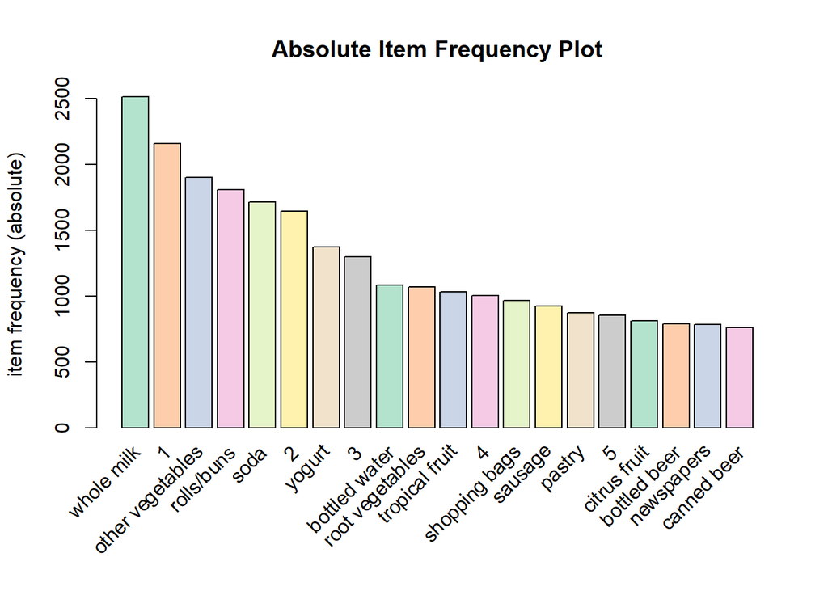

```r
#Create an item frequency plot for the top 10 items

if (!require("RColorBrewer")) {
  # install color package of R
install.packages("RColorBrewer")
#include library RColorBrewer
library(RColorBrewer)
}
itemFrequencyPlot(tr,topN=20,type="absolute",col=brewer.pal(8,'Pastel2'), main="Absolute Item Frequency Plot")
```

```r
# absolute type parameter gives  us numeric frequencies of items  independently
```

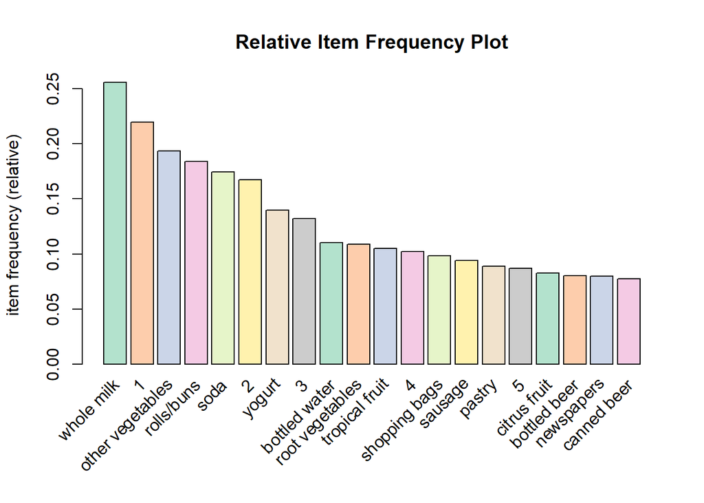

```r
itemFrequencyPlot(tr,topN=20,type="relative",col=brewer.pal(8,'Pastel2'),main="Relative Item Frequency Plot")
```

```r
#relative type parameter the number of times an item has appeared as compared to others
```

# since whole milk has the highest sales bringing youghurt next to milk and 1 item will increase its sales.

# root vegestable should be positioned next to other vegetables to increase its sales.

# citrus fruits should be placed close to tropicalfruit and bottkled water which has more sales

# generating rules using Apriori algorythm

```r
# Min Support as 0.001, confidence as 0.8. which are the default values and max of 10 items
association.rules <- apriori(tr, parameter = list(supp=0.001, conf=0.8,maxlen=10))
```

```
## Apriori
##
## Parameter specification:
##  confidence minval smax arem  aval originalSupport maxtime support minlen
##         0.8    0.1    1 none FALSE            TRUE       5   0.001      1
##  maxlen target  ext
##      10  rules TRUE
##
## Algorithmic control:
##  filter tree heap memopt load sort verbose
##     0.1 TRUE TRUE  FALSE TRUE    2    TRUE
##
## Absolute minimum support count: 9
##
## set item appearances ...[0 item(s)] done [0.00s].
## set transactions ...[231 item(s), 9836 transaction(s)] done [0.01s].
## sorting and recoding items ... [177 item(s)] done [0.00s].
## creating transaction tree ... done [0.01s].
## checking subsets of size 1 2 3 4 5 6 done [0.04s].
## writing ... [463 rule(s)] done [0.00s].
## creating S4 object  ... done [0.01s].
```

```r
summary(association.rules)
```

```
## set of 463 rules
##
## rule length distribution (lhs + rhs):sizes
##   3   4   5   6
##  47 259 145  12
##
##    Min. 1st Qu.  Median    Mean 3rd Qu.    Max.
##   3.000   4.000   4.000   4.263   5.000   6.000
##
## summary of quality measures:
##     support           confidence        coverage             lift
##  Min.   :0.001017   Min.   :0.8000   Min.   :0.001017   Min.   : 3.131
##  1st Qu.:0.001017   1st Qu.:0.8333   1st Qu.:0.001220   1st Qu.: 3.312
##  Median :0.001118   Median :0.8462   Median :0.001322   Median : 3.588
##  Mean   :0.001242   Mean   :0.8663   Mean   :0.001444   Mean   : 3.933
##  3rd Qu.:0.001322   3rd Qu.:0.9091   3rd Qu.:0.001627   3rd Qu.: 4.307
##  Max.   :0.003152   Max.   :1.0000   Max.   :0.003558   Max.   :11.236
##      count
##  Min.   :10.00
##  1st Qu.:10.00
##  Median :11.00
##  Mean   :12.22
##  3rd Qu.:13.00
##  Max.   :31.00
##
## mining info:
##  data ntransactions support confidence
##    tr          9836   0.001        0.8
##                                                                         call
##  apriori(data = tr, parameter = list(supp = 0.001, conf = 0.8, maxlen = 10))
```

```r
#
```

# the total number of rules are 463

# Distribution of rule length - rule with length of 4 has the highest number of rules while that with lenght of 6 has the lowest number of rules.

#inspecting the rules

```r
# printing  the first 8 rules
inspect(association.rules[1:8])
```

```
##     lhs                         rhs            support     confidence
## [1] {17, tropical fruit}     => {whole milk}   0.001118341 1.0000000
## [2] {cereals, curd}          => {whole milk}   0.001016673 0.9090909
## [3] {cereals, yogurt}        => {whole milk}   0.001728345 0.8095238
## [4] {butter, jam}            => {whole milk}   0.001016673 0.8333333
## [5] {liquor, red/blush wine} => {bottled beer} 0.001931680 0.9047619
## [6] {bottled beer, soups}    => {whole milk}   0.001118341 0.9166667
## [7] {7, specialty cheese}    => {whole milk}   0.001016673 0.9090909
## [8] {16, whipped/sour cream} => {whole milk}   0.001220008 0.8571429
##     coverage    lift      count
## [1] 0.001118341  3.914047 11
## [2] 0.001118341  3.558225 10
## [3] 0.002135014  3.168514 17
## [4] 0.001220008  3.261706 10
## [5] 0.002135014 11.236412 19
## [6] 0.001220008  3.587876 11
## [7] 0.001118341  3.558225 10
## [8] 0.001423343  3.354897 12
```

```r
#
```

# 100% of customers of who bought (17,tropical fruit) also bought whole milk

#91% of those who bought cereals and curd bought whole milk # 85% of those who bought {16, whipped/sour cream} also bought whole milk

```r
#To find out which items are likely to be purchased with whole milk:
rules<-apriori(data=tr, parameter=list(supp=0.001,conf = 0.8),
 appearance = list(default="lhs",rhs="whole milk"),
 control = list(verbose=F))
 rules<-sort(rules, decreasing=TRUE,by="confidence")
 inspect(rules[1:6])
```

```
##     lhs                     rhs              support confidence    coverage     lift count
## [1] {17,
##      tropical fruit}     => {whole milk} 0.001118341          1 0.001118341 3.914047    11
## [2] {rice,
##      sugar}              => {whole milk} 0.001220008          1 0.001220008 3.914047    12
## [3] {canned fish,
##      hygiene articles}   => {whole milk} 0.001118341          1 0.001118341 3.914047    11
## [4] {butter,
##      rice,
##      root vegetables}    => {whole milk} 0.001016673          1 0.001016673 3.914047    10
## [5] {14,
##      curd,
##      other vegetables}   => {whole milk} 0.001016673          1 0.001016673 3.914047    10
## [6] {flour,
##      root vegetables,
##      whipped/sour cream} => {whole milk} 0.001728345          1 0.001728345 3.914047    17
```

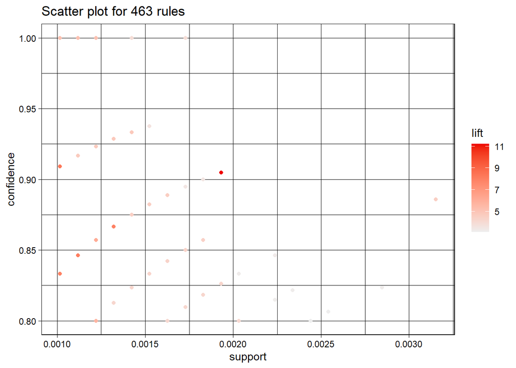

```r
# Filter rules with confidence greater than 0.6 or 60%
subRules<-association.rules[quality(association.rules)$confidence>0.6]
#Plot SubRules
plot(subRules,jitter=0)
```

```r
# rules with high lift have low surpport
```

## rules with high lift have low surpport while rules with lo lift have high surppport

# plot using 2-key- plot

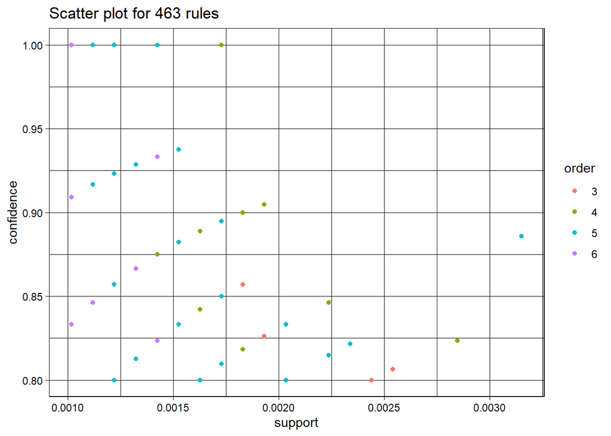

```r
# using confidence as y and surpport as x
plot(subRules,method="two-key plot",jitter= 0)
```

```r
## order is the number of items in a rule
```

#rule with 6 items has low support which means a rule with more items has low suppport than a rule with few items

# graph Based visualizations

```r
top10subRules <- head(subRules, n = 10, by = "confidence")

plot(top10subRules, method = "graph",  engine = "htmlwidget")
```

[interactive chart not shown]